# A1

Felix Shier

24/01/2022

# Part 1: Feature Selection and Multicollinearity Analysis

## Initial Set Up

```r
# imports
require(ggplot2)
require(stringr)
require(caret)
require(plyr)
require(data.table)
require(dplyr)
require(tidyr)
require(tidyverse)
# alter plot size
knitr::opts_chunk$set(fig.width=20, fig.height=8)
```

```r
# import data
filenames <- list.files("Assignment1-dataset", pattern="*.csv", full.names = TRUE)
ldf <- lapply(filenames, read.csv, fileEncoding="UTF-8-BOM", check.names = FALSE)
names(ldf) <- str_replace_all(basename(filenames), ".csv", "")
```

```r
# combine dataframes
df <- rbindlist(ldf)
```

[output not shown]

```r
# remove \n from column names
colnames(df) <- str_replace_all(colnames(df), "\n", "")
colnames(df) <- str_replace_all(colnames(df), " ", "_")
colnames(df) <- tolower(colnames(df))
```

```r
colnames(df)
```

```
##  [1] "borough"
##  [2] "neighborhood"
##  [3] "building_class_category"
##  [4] "tax_class_as_of_final_roll_18/19"
##  [5] "block"
##  [6] "lot"
##  [7] "ease-ment"
##  [8] "building_class_as_of_final_roll_18/19"
##  [9] "address"
## [10] "apartment_number"
## [11] "zip_code"
## [12] "residential_units"
## [13] "commercial_units"
## [14] "total_units"
## [15] "land_square_feet"
## [16] "gross_square_feet"
## [17] "year_built"
## [18] "tax_class_at_time_of_sale"
## [19] "building_class_at_time_of_sale"
## [20] "sale_price"
## [21] "sale_date"
```

## Data Exploration

To begin this assignment, I will explore the data in order to determine what cleaning needs to be done prior to analysis.

```r
# view data head
head(df)
```

```
##    borough neighborhood building_class_category
## 1:       2     BATHGATE 01 ONE FAMILY DWELLINGS
## 2:       2     BATHGATE 01 ONE FAMILY DWELLINGS
## 3:       2     BATHGATE 01 ONE FAMILY DWELLINGS
## 4:       2     BATHGATE 01 ONE FAMILY DWELLINGS
## 5:       2     BATHGATE 01 ONE FAMILY DWELLINGS
## 6:       2     BATHGATE 01 ONE FAMILY DWELLINGS
##    tax_class_as_of_final_roll_18/19 block lot ease-ment
## 1:                                1  2907  24        NA
## 2:                                1  3030  62        NA
## 3:                                1  3030  62        NA
## 4:                                1  3030  70        NA
## 5:                                1  3039  28        NA
## 6:                                1  3039  63        NA
##    building_class_as_of_final_roll_18/19                  address
```

[output cut: 27 more lines]

```r
# statistical summary
summary(df)
```

```
##     borough      neighborhood       building_class_category
##  Min.   :1.00    Length:277803      Length:277803
##  1st Qu.:2.00    Class :character   Class :character
##  Median :3.00    Mode  :character   Mode  :character
##  Mean   :3.02
##  3rd Qu.:4.00
##  Max.   :5.00
##  NA's   :47144
##  tax_class_as_of_final_roll_18/19     block            lot
##  Length:277803                    Min.   :    1   Min.   :   1.0
##  Class :character                 1st Qu.: 1366   1st Qu.:  22.0
##  Mode  :character                 Median : 3558   Median :  49.0
##                                   Mean   : 4422   Mean   : 357.5
##                                   3rd Qu.: 6574   3rd Qu.: 316.0
##                                   Max.   :16350   Max.   :9116.0
##                                   NA's   :47144   NA's   :47144
##  ease-ment      building_class_as_of_final_roll_18/19   address
##  Mode:logical   Length:277803                         Length:277803
##  NA's:277803    Class :character                      Class :character
##                 Mode  :character                      Mode  :character
##
##
##
##
##  apartment_number      zip_code     residential_units  commercial_units
##  Length:277803      Min.   :    0   Length:277803      Length:277803
##  Class :character   1st Qu.:10307   Class :character   Class :character
##  Mode  :character   Median :11210   Mode  :character   Mode  :character
##                     Mean   :10845
##                     3rd Qu.:11358
##                     Max.   :11697
##                     NA's   :47161
##  total_units        land_square_feet   gross_square_feet    year_built
##  Length:277803      Length:277803      Length:277803      Min.   :   0
##  Class :character   Class :character   Class :character   1st Qu.:1921
##  Mode  :character   Mode  :character   Mode  :character   Median :1941
##                                                           Mean   :1893
##                                                           3rd Qu.:1970
##                                                           Max.   :2021
##                                                           NA's   :57430
##  tax_class_at_time_of_sale building_class_at_time_of_sale  sale_price
##  Min.   :1.00              Length:277803                  Length:277803
##  1st Qu.:1.00              Class :character               Class :character
##  Median :1.00              Mode  :character               Mode  :character
##  Mean   :1.62
##  3rd Qu.:2.00
##  Max.   :4.00
##  NA's   :47144
##   sale_date
##  Length:277803
##  Class :character
##  Mode  :character
##
##
##
##
```

From looking at these summaries, it appears there are several issues which should be investigated further. Primarily:

- column names
- data types
- missing values

## Data Cleaning

### Column Names

Firstly, it should be noted that with the method of binding performed, I am combining the columns from 2018 and 2019 which end in “FINAL ROLL 18/19” and the columns from 2020 which end in “PRESENT”. This assumption is being made as these columns (building class, tax class) are unlikely to change and can thus be stored under more generic column names.

```r
# change column names
names(df)[names(df) == "tax_class_as_of_final_roll_18/19"] <- "tax_class"
names(df)[names(df) == "building_class_as_of_final_roll_18/19"] <- "building_class"
```

### Data Types

From looking at the summaries of the different columns, it appears certain columns are not storing their data in an optimal data type. Specifically, the following transformations should be made:

- residential_units (character -> integer)
- commercial_units (character -> integer)
- total_units (character -> integer)
- land_square_feet (character -> integer)
- gross_square_feet (character -> integer)
- sale_price (character -> integer)
- sale_date (character -> date)

```r
# remove unwanted characters
df$residential_units <- str_replace_all(df$residential_units, ",", "")
df$commercial_units <- str_replace_all(df$commercial_units, ",", "")
df$total_units <- str_replace_all(df$total_units, ",", "")
df$land_square_feet <- str_replace_all(df$land_square_feet, ",", "")
df$gross_square_feet <- str_replace_all(df$gross_square_feet, ",", "")
df$sale_price <- str_replace_all(df$sale_price, ",", "")
df$sale_price <- str_replace_all(df$sale_price, "[$]", "")

# change column data types
df$residential_units <- as.integer(df$residential_units)
df$commercial_units <- as.integer(df$commercial_units)
df$total_units <- as.integer(df$total_units)
df$land_square_feet <- as.integer(df$land_square_feet)
df$gross_square_feet <- as.integer(df$gross_square_feet)
df$sale_price <- as.integer(df$sale_price)
df$sale_date <- as.Date(df$sale_date)
```

### Missing Values

```r
# count missing values
na_count <-sapply(df, function(x) sum(length(which(is.na(x)))))
na_count <- data.frame(na_count)
na_count
```

```
##                                na_count
## borough                           47144
## neighborhood                          0
## building_class_category               0
## tax_class                             0
## block                             47144
## lot                               47144
## ease-ment                        277803
## building_class                        0
## address                               0
## apartment_number                      0
## zip_code                          47161
## residential_units                 78069
## commercial_units                  88535
## total_units                       76440
## land_square_feet                  90165
## gross_square_feet                 90164
## year_built                        57430
## tax_class_at_time_of_sale         47144
## building_class_at_time_of_sale        0
## sale_price                        47146
## sale_date                         47144
```

Looking at this information, a couple changes can be made right away.

Firstly, rows with missing sale_price data should be removed as that information is critical to this analysis.

Secondly, the ease-ment column is filled entirely with NA values which is not useful, so that column can be removed.

```r
# remove rows with missing sale_price data
df <- df %>% drop_na(sale_price)

# remove ease-ment column
df <- select(df, -c("ease-ment"))
```

```r
# count missing values
na_count <-sapply(df, function(x) sum(length(which(is.na(x)))))
na_count <- data.frame(na_count)
na_count
```

```
##                                na_count
## borough                               0
## neighborhood                          0
## building_class_category               0
## tax_class                             0
## block                                 0
## lot                                   0
## building_class                        0
## address                               0
## apartment_number                      0
## zip_code                             17
## residential_units                 30925
## commercial_units                  41391
## total_units                       29296
## land_square_feet                  43021
## gross_square_feet                 43020
## year_built                        10286
## tax_class_at_time_of_sale             0
## building_class_at_time_of_sale        0
## sale_price                            0
## sale_date                             0
```

Additionally, it can now be noted that only 17 rows are missing zip_code data. This is minimal and these rows can be removed.

```r
# remove rows with missing zip_code data
df <- df %>% drop_na(zip_code)
```

First I will investigate the unit columns. It can be noted that if 2/3 columns are filled the 3rd can be inferred.

```r
# if tot is empty replace with res + com
df$total_units[is.na(df$total_units) & !is.na(df$residential_units) & !is.na(df$commercial_units)] <- df$residential_units[is.na(df$total_units) & !is.na(df$residential_units) & !is.na(df$commercial_units)] + df$commercial_units[is.na(df$total_units) & !is.na(df$residential_units) & !is.na(df$commercial_units)]

# if res is empty replace with tot - com
df$residential_units[is.na(df$residential_units) & !is.na(df$total_units) & !is.na(df$commercial_units)] <- df$total_units[is.na(df$residential_units) & !is.na(df$total_units) & !is.na(df$commercial_units)] - df$commercial_units[is.na(df$residential_units) & !is.na(df$total_units) & !is.na(df$commercial_units)]

# if com is empty replace with tot - res
df$commercial_units[is.na(df$commercial_units) & !is.na(df$total_units) & !is.na(df$residential_units)] <- df$total_units[is.na(df$commercial_units) & !is.na(df$total_units) & !is.na(df$residential_units)] - df$residential_units[is.na(df$commercial_units) & !is.na(df$total_units) & !is.na(df$residential_units)]
```

There is still a significant amount of rows that are missing data in all 3 columns. Looking at the histograms of these columns for specific building classes shows that the number of units are typically the same across each specific building type. This is shown in a few histograms below. Therefore, to handle the missing values for these columns, I will replace the missing values with the mode of it’s building class.

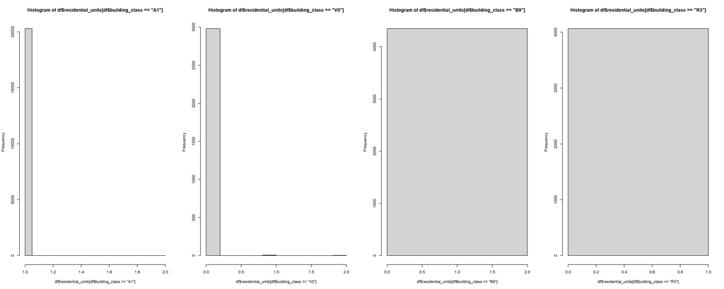

```r
# create 1x4 figure
par(mfrow=c(1,4))

hist(df$residential_units[df$building_class == "A1"])
hist(df$residential_units[df$building_class == "V0"])
hist(df$residential_units[df$building_class == "B9"])
hist(df$residential_units[df$building_class == "R3"])
```

```r
# create mode function
getmode <- function(x) {
   uniqx <- unique(x)
   uniqx[which.max(tabulate(match(x, uniqx)))]
}

# impute missing residential_units and commercial_units data with mode
impute.mode <- function(x) replace(x, is.na(x), getmode(x))
df <- df %>%
    group_by(building_class) %>%
    mutate(residential_units = impute.mode(residential_units),
           commercial_units = impute.mode(commercial_units))

# if tot is empty replace with res + com
df$total_units[is.na(df$total_units) & !is.na(df$residential_units) & !is.na(df$commercial_units)] <- df$residential_units[is.na(df$total_units) & !is.na(df$residential_units) & !is.na(df$commercial_units)] + df$commercial_units[is.na(df$total_units) & !is.na(df$residential_units) & !is.na(df$commercial_units)]
```

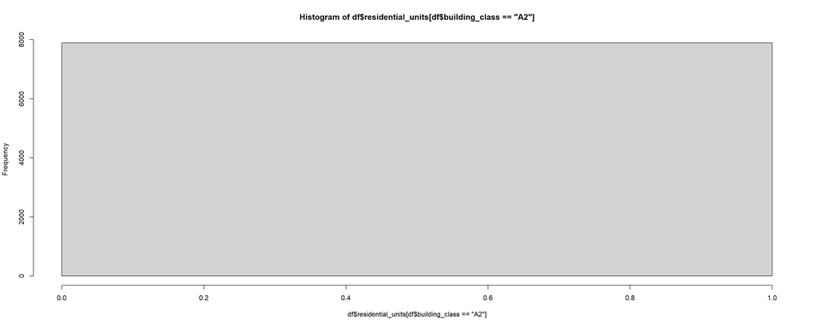

```r
hist(df$residential_units[df$building_class == "A2"])
```

```r
# impute missing residential_units and commercial_units data with mean
impute.mean <- function(x) replace(x, is.na(x), mean(x, rm.na = TRUE))
df <- df %>%
    group_by(building_class) %>%
    mutate(land_square_feet = impute.mean(land_square_feet),
           gross_square_feet = impute.mean(gross_square_feet))
```

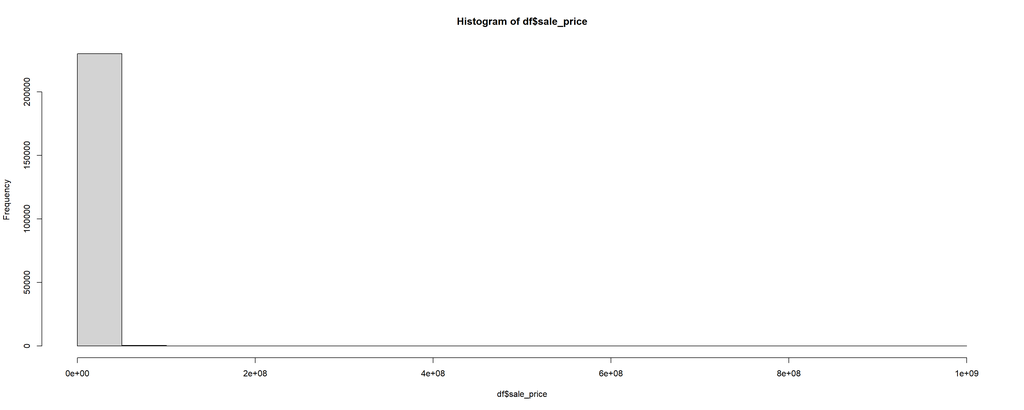

```r
# data exploration
hist(df$sale_price)
```

```r
# get training and testing data

# choose buroughs 1 and 2 for testing
test_boroughs = df[df$borough == 1 | df$borough == 2, ]

test_size <- floor(0.1 * nrow(test_boroughs))
test_ind <- sample(seq_len(nrow(test_boroughs)), size = test_size)

test_set <- test_boroughs[test_ind, ]
train_set <- df[-test_ind, ]
```